# Copula Null-Model Sampling

Xinrui Shi

2026-08-04

# Empirical inputs

This report reads the empirical outputs produced by `empirical_database.Rmd`. It does not read the original saved summary metrics from the legacy workflow.

## Sampled joint-MNS networks

The dependence among `(M,N,S)` is estimated with a three-dimensional Gaussian copula fitted by maximum pseudo-likelihood. Type-1 empirical quantiles retain the three observed marginal distributions.

Fitted Gaussian-copula dependence parameters

| Parameter | Estimate |
| --- | --- |
| rho.1 | 0.5259 |
| rho.2 | 0.9935 |
| rho.3 | 0.5498 |

# Failure summary

We obtained 300 qualified null-model networks after sampling 378 joint parameter tuples $(M,N,S)$. 78 tuples did not produce a qualified network: 78 were structurally infeasible before allocation, and 0 were feasible tuples that still failed after all allocation and rewiring attempts.

The simulation does **not** explicitly impose $M \geq 2$ or $N \geq 4$ as rejection rules. Instead, both requirements are automatically satisfied by the empirical margins used after the copula draw: the observed minimum is $M=2$ and the observed minimum is $N=4$. Because the sampler uses type-1 empirical quantiles, it cannot generate values below those minima. The table below reports how often these conditions and the edge-count conditions occurred among all sampled tuples and among rejected tuples. Conditions can overlap, so the rows must not be added.

For the tuples that passed the structural check, the algorithm sampled 300 initial edge allocations on its way to the final 300 networks. Before any repair, these allocations experienced the defects shown in the second table. These counts are also non-exclusive: one allocation can be both disconnected and have low trial or treatment degree. The $S<2M$ count is zero at the allocation stage because such a tuple is rejected before an allocation is attempted; its total occurrence is shown in the tuple-condition table.

All final networks are checked again after rewiring. Therefore, the third table directly answers how many of the 300 qualified networks are disconnected or violate either degree constraint.

Overall generation outcome

| Quantity | Count |
| --- | --- |
| Qualified networks | 300 |
| Joint (M,N,S) tuples sampled | 378 |
| Tuples not producing a qualified network | 78 |
| Structurally infeasible tuples | 78 |
| Feasible tuples exhausting generation attempts | 0 |

Conditions observed in sampled (M,N,S) tuples

| Condition | All sampled tuples | Rejected tuples |
| --- | --- | --- |
| M < 2 (excluded automatically by empirical margin) | 0 | 0 |
| N < 4 (excluded automatically by empirical margin) | 0 | 0 |
| S < 2M | 69 | 69 |
| S < N | 0 | 0 |
| S < M + N - 1 | 10 | 10 |
| S > MN | 0 | 0 |

Defects observed across 300 initial edge allocations

| Defect | Count |
| --- | --- |
| Disconnected | 223 |
| S < 2M | 0 |
| At least one trial has degree < 2 | 295 |
| At least one treatment has degree < 1 | 45 |

Defects in the final 300 qualified networks

| Defect | Count |
| --- | --- |
| Disconnected | 0 |
| S < 2M | 0 |
| At least one trial has degree < 2 | 0 |
| At least one treatment has degree < 1 | 0 |

## Failures requiring targeted rewiring by number of treatments

The plot below is restricted to networks that ultimately qualified. For each number of treatments, it counts networks whose initial allocation failed at least one qualification check and therefore required targeted rewiring (`rewiring_attempts > 0`).

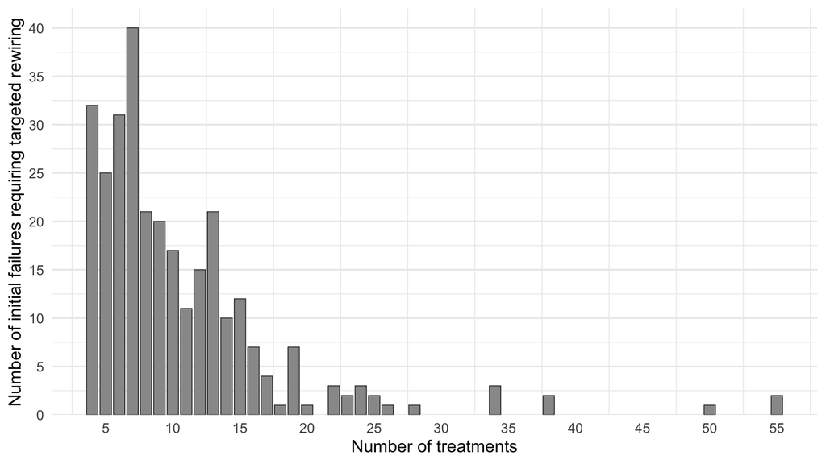

## Rewired edges by number of treatments: separate 10,000-network sample

This diagnostic uses a separate copula sample and continues until 10,000 qualified networks have been generated. A moved edge counts as one rewired edge in the trial- or treatment-degree repair. A double-edge swap used to join components counts as two rewired edges. The total is the sum across the three repair targets. Initially valid networks are retained with zero rewired edges, so each mean describes all qualified networks at that value of $N$.

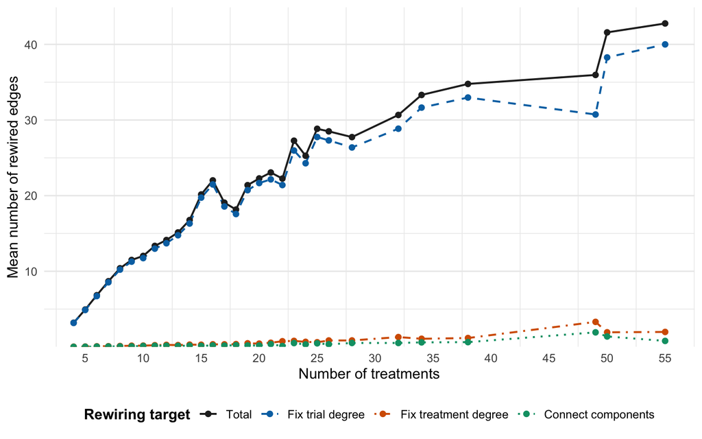

For the proportional version, each network’s rewired-edge count is divided by its total number of bipartite edges, $S$, before averaging across qualified networks with the same $N$. Thus, the denominator is the realised number of trial–treatment edges in that network rather than the number of possible edges, $MN$.

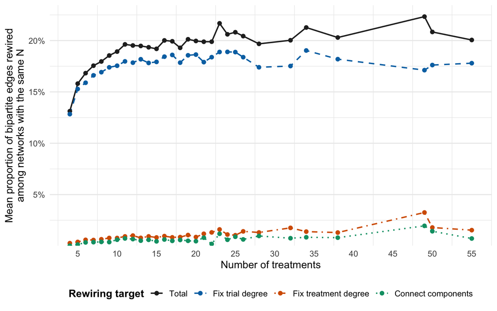

# Verification check plots

## Numbers of trials and treatments

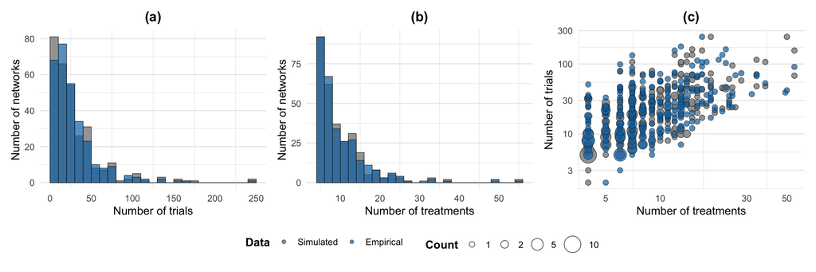

## Number of bipartite edges and joint relationships

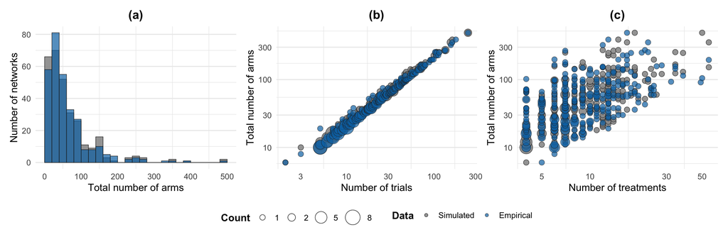

# Compute sampled-network metrics

Metrics and degree vectors are computed here and saved for `metrics comparison.Rmd`. The comparison report does not reopen or analyse the network matrices.

```
## Sampled networks with saved metrics: 300
```

## Fitted-line parameters for the comparison report

The regression parameters are prepared here so the comparison report can load the saved table directly.